# Sawfish

## Supplementing length data

By using the rostrum length to infer the total length we could increase the sample size by 6. It’s not a dramatic increase, but given the paucity of data it seems to be a valuable exercise. Details of those observations are shown below.

```r
drake::loadd(encounters)
encounters %>%
  count(is.na(rostrum_length_cm), is.na(total_length_cm), is.na(reported_collection_year))
```

```
## # A tibble: 8 x 4
##   `is.na(rostrum_length_… `is.na(total_length_… `is.na(reported_collectio…     n
##   <lgl>                   <lgl>                 <lgl>                      <int>
## 1 FALSE                   FALSE                 FALSE                          7
## 2 FALSE                   FALSE                 TRUE                           3
## 3 FALSE                   TRUE                  FALSE                          6
## 4 FALSE                   TRUE                  TRUE                          12
## 5 TRUE                    FALSE                 FALSE                         43
## 6 TRUE                    FALSE                 TRUE                           3
## 7 TRUE                    TRUE                  FALSE                        153
## 8 TRUE                    TRUE                  TRUE                          21
```

```r
encounters %>%
  filter(is.na(total_length_cm), !is.na(rostrum_length_cm), !is.na(reported_collection_year)) %>%
  select(country, species, ocean, sex, source_type)
```

```
## # A tibble: 6 x 5
##   country  species         ocean   sex     source_type
##   <chr>    <chr>           <chr>   <chr>   <chr>
## 1 Panama   Pristis pristis pacific unknown Literature
## 2 Panama   Pristis pristis pacific unknown Interview
## 3 Panama   Pristis pristis pacific unknown Non-interview observation
## 4 Panama   Pristis pristis pacific unknown Museum Collection
## 5 Panama   Pristis pristis pacific unknown ISED
## 6 Colombia Pristis sp.     unknown unknown ISED
```

## Allometric relationship

We use another model to the allometric relationship between rostrum and total length. This allows us to estimate the total length for those encounters that only have rostrum length. As expected the uncertainty is larger when the species is not known. Note that this would be greatly improved if we could source existing data from the literature.

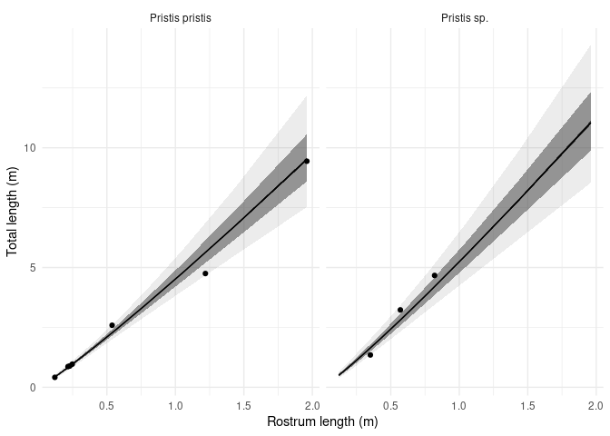

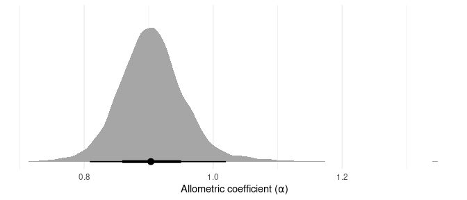

```r
coefficients <- spread_draws(allometric_model, b_Intercept, b_rostrum_length_cm) %>%
  mutate(alpha = 1 / b_rostrum_length_cm,
         log_b = b_Intercept / b_rostrum_length_cm * (-1)) %>%
  select(-b_Intercept, -b_rostrum_length_cm)


coefficients %>%
  ggplot(aes(x = alpha)) +
  stat_halfeye() +
  theme_minimal() +
  theme(axis.title.y = element_blank(),
        axis.text.y = element_blank(),
        panel.grid.major.y = element_blank(),
        panel.grid.minor.y = element_blank()) +
  labs(x = "Allometric coefficient (⍺)")
```

## Length data

Let’s explore the data using different strata. This will allow us to better identify how data is distributed across different categories and which ones have the potential to introduce biases in the data.

Most available length-year data is from *Pristis pristis* in the Panama’s Pacific. There is also a strong bias of the year of different source types. It would be important to take these biases into account.

In addition a group of records from museums that have small individuals (< 1.5 meters) that might not be easily explained by the current strata. Similar cases for literature sourced encounters where a range of sizes is available for a given year.

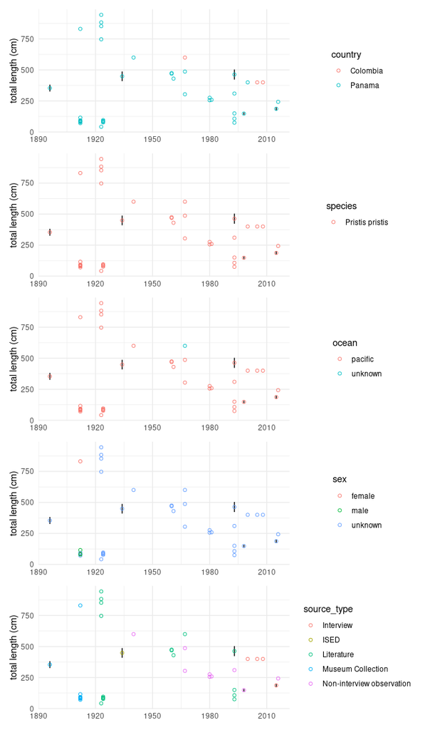

```r
drake::loadd(length_model_data)

bp <-  length_model_data %>%
  filter(!is.na(reported_collection_year), !is.na(total_length_cm)) %>%
  ggplot(aes(x = reported_collection_year, y = total_length_cm)) +
  geom_linerange(aes(ymin = total_length_cm - total_length_cm_se,
                     ymax = total_length_cm + total_length_cm_se)) +
  theme_minimal() +
  theme(axis.title.x = element_blank()) +
  labs(y = "total length (cm)")

p1 <- bp + geom_point(aes(colour = country), shape = 21)
p2 <- bp + geom_point(aes(colour = species), shape = 21)
p3 <- bp + geom_point(aes(colour = ocean), shape = 21)
p4 <- bp + geom_point(aes(colour = sex), shape = 21)
p5 <- bp + geom_point(aes(colour = source_type), shape = 21)

p1 + p2 + p3 + p4 + p5 + plot_layout(ncol = 1)
```

## Model results

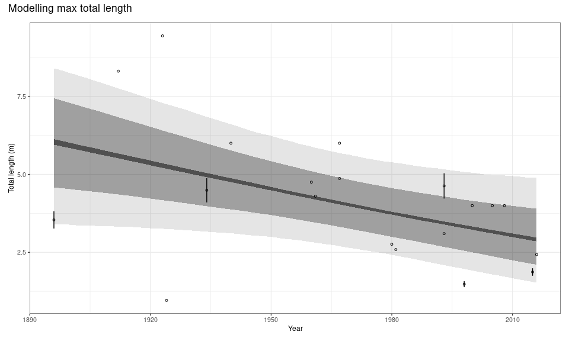

```r
drake::readd(fig_max_length_vs_time) +
  plot_annotation(title = "Modelling max total length")
```

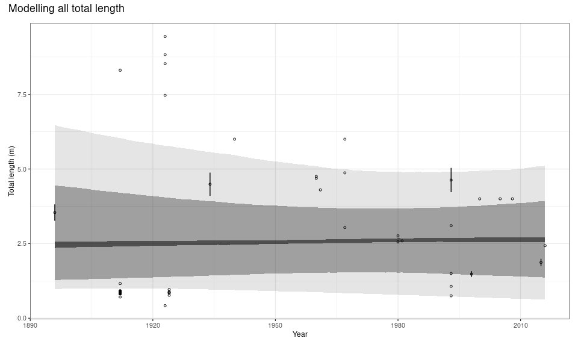

```r
drake::readd(fig_length_vs_time) +
  plot_annotation(title = "Modelling all total length")
```

## Encounters

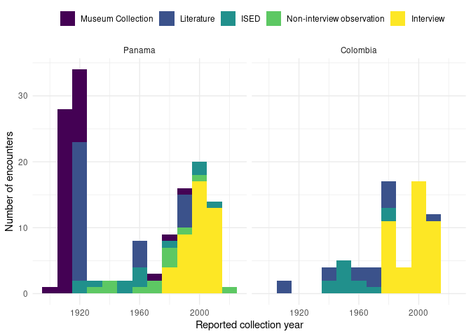

```r
drake::loadd(encounters)

enc_data <- encounters %>%
  filter(reported_collection_year > 1800) %>%
  mutate(source_type = fct_reorder(source_type, reported_collection_year, median),
         country = fct_infreq(country))

enc_data %>%
  ggplot(aes(x = reported_collection_year, fill = source_type)) +
  geom_histogram(binwidth = 10, center = 2000) +
  facet_wrap("country", ncol = 2) +
  # scale_fill_brewer(palette = "Set1") +
  # scale_y_continuous(sec.axis = sec_axis(~ . / nrow(enc_data),
                                         # labels = scales::label_percent(), name = "Percentage of encounters")) +
  scale_fill_viridis_d() +
  # scale_x_binned(stat  = "co") +
  theme_minimal() +
  theme(legend.position = "top",
        legend.title = element_blank()) +
  labs(x = "Reported collection year",
       y = "Number of encounters")
```

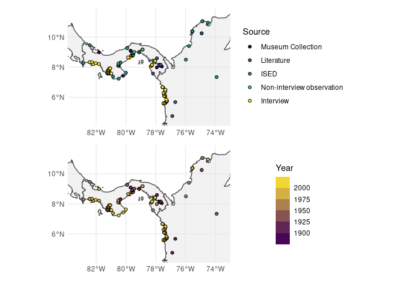

```r
library(rnaturalearth)
library(rnaturalearthhires)
world <- ne_countries(country = c("Colombia", "Panama", "Costa Rica"), scale = "large", returnclass = "sf")

map_data <-
  encounters %>%
    filter(reported_collection_year > 1800) %>%
  mutate(source_type = fct_reorder(source_type, reported_collection_year, median),
         across(c(longitude, latitude), as.numeric)) %>%
  filter(latitude > 0)
p1 <- ggplot(data = map_data) +
  geom_sf(data = world, inherit.aes = F, alpha = 0.5, colour = "grey30") +
  geom_point(data = map_data, aes(x = longitude, y = latitude, fill = source_type), shape = 21) +
  scale_fill_viridis_d() +
  theme_minimal() +
  theme(axis.title = element_blank()) +
  coord_sf(xlim = c(-83.9, -73), ylim = c(4.1, 11.9), expand = FALSE) +
  scale_x_continuous(breaks = seq(-90, 90, by = 2)) +
  scale_y_continuous(breaks = seq(-90, 90, by = 2)) +
  labs(fill = "Source")

p2 <- ggplot(data = map_data) +
  geom_sf(data = world, inherit.aes = F, alpha = 0.5, colour = "grey30") +
  geom_point(data = map_data, aes(x = longitude, y = latitude, fill = reported_collection_year), shape = 21) +
  scale_fill_stepsn(breaks = seq(1000, 3000, by = 25), colours = viridis::viridis(2)) +
  theme_minimal() +
  theme(axis.title = element_blank()) +
  coord_sf(xlim = c(-83.9, -73), ylim = c(4.1, 11.9), expand = FALSE) +
  scale_x_continuous(breaks = seq(-90, 90, by = 2)) +
  scale_y_continuous(breaks = seq(-90, 90, by = 2)) +
  labs(fill = "Year")

p1 + p2 + plot_layout(ncol = 1)
```